# **RESEARCH**

```python
#Libraries imported
import numpy as np
import pandas as pd
from sklearn.feature_extraction.text import CountVectorizer
from sklearn import metrics
from sklearn.model_selection import train_test_split
from sklearn.linear_model import LogisticRegression
```

# **DATA EXPLORATION**

This section contains the study of the details of the dataset along with data pre-processing.

```python
#read the csv file and the description of each column
file = pd.read_csv("/content/drive/My Drive/data/data.csv")
file.info()
```

```
<class 'pandas.core.frame.DataFrame'>
RangeIndex: 66 entries, 0 to 65
Data columns (total 5 columns):
 #   Column                Non-Null Count  Dtype
---  ------                --------------  -----
 0   Favorite Color        66 non-null     object
 1   Favorite Music Genre  66 non-null     object
 2   Favorite Beverage     66 non-null     object
 3   Favorite Soft Drink   66 non-null     object
 4   Gender                66 non-null     object
dtypes: object(5)
memory usage: 2.7+ KB
```

```python
file.head()
```

|  | Favorite Color | Favorite Music Genre | Favorite Beverage | Favorite Soft Drink | Gender |
| --- | --- | --- | --- | --- | --- |
| 0 | Cool | Rock | Vodka | 7UP/Sprite | F |
| 1 | Neutral | Hip hop | Vodka | Coca Cola/Pepsi | F |
| 2 | Warm | Rock | Wine | Coca Cola/Pepsi | F |
| 3 | Warm | Folk/Traditional | Whiskey | Fanta | F |
| 4 | Cool | Rock | Vodka | Coca Cola/Pepsi | F |

# **Data Visualization**

```python
import seaborn as sns
import matplotlib.pyplot as plt
```

Seaborn is a Python data visualization library based on matplotlib. It provides a high-level interface for drawing attractive and informative statistical graphics.

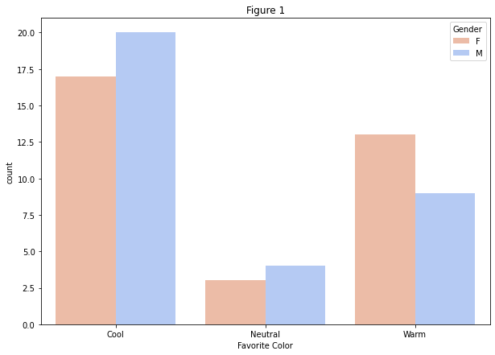

```python
plt.figure(figsize=(10,7))
color=sns.countplot('Favorite Color', hue='Gender', data=file, palette='coolwarm_r')
color.set_title('Figure 1')
```

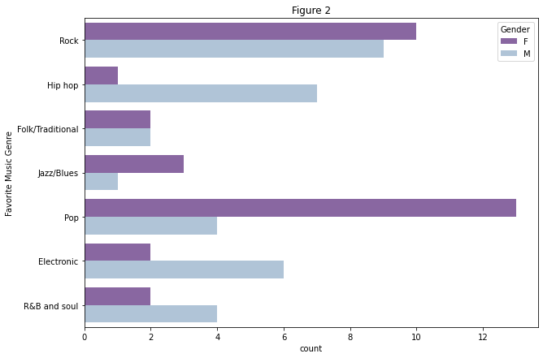

```python
plt.figure(figsize=(10,7))
music=sns.countplot(y='Favorite Music Genre', hue='Gender', data=file, palette='BuPu_r');
music.set_title('Figure 2')
```

> *Figure 2. The data seems to indicate that females might prefer rock, jazz/blues and pop over males, who might prefer R&B/soul, electronic and hip hop music.*

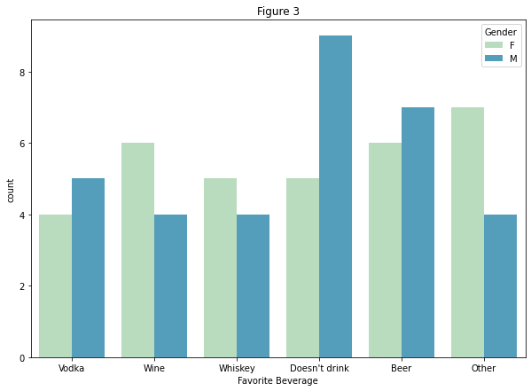

```python
plt.figure(figsize=(10,7))
drink=sns.countplot('Favorite Beverage', hue='Gender', data=file, palette='GnBu');
drink.set_title('Figure 3')
```

> *Figure 3. It appears to be more likely that people who don't drink will be males. If that were so, one plausible interpretation would be that people who do not drink might belong to a conservative culture.*

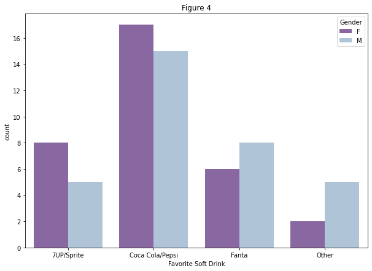

```python
plt.figure(figsize=(10,7))
sdrinks=sns.countplot('Favorite Soft Drink', hue='Gender', data=file, palette='BuPu_r');
sdrinks.set_title('Figure 4')
```

> *Figure 4. It is evident that Cocacola and Pepsi are the most preferred soft drinks on both gender. It might be the case that 7UP/Sprite is more popular with females while Fanta is more popular with males.*

In this step, the categorical data was converted into numerical data by factorization. This method counts the unique values and assign a corresponding numerical value to each of them.

```python
#rename dataset
file.rename(columns={'Favorite Color' :'FavoriteColor', 'Favorite Music Genre':'FavoriteMusicGenre',
                          'Favorite Beverage':'FavoriteBeverage', 'Favorite Soft Drink':'FavoriteSoftDrink'}, inplace=True)

#factorize categorical columns
file['FavoriteColor'],_ = pd.factorize(file['FavoriteColor'])
file['FavoriteMusicGenre'],_ = pd.factorize(file['FavoriteMusicGenre'])
file['FavoriteBeverage'],_ = pd.factorize(file['FavoriteBeverage'])
file['FavoriteSoftDrink'],_ = pd.factorize(file['FavoriteSoftDrink'])
```

```python
# assign dependent and independent variable
X = file.drop(['Gender'], axis = 1)
y = file.Gender
```

# **MODELING**

This section is where the data was seperated randomly into testing(30%) and training(70%) sets.

```python
from sklearn.model_selection import train_test_split
X_train, X_test, y_train, y_test = train_test_split(X, y, test_size=0.30, random_state=42)
```

This part includes the training of the dataset where the models are trained and the accuracy was measured. Parameters are experimented and adjusted in order to increase the accuracy.

```python
from sklearn.datasets import make_classification
X, y = make_classification(n_samples=1000, n_features=20, n_informative=15, n_redundant=5, random_state=6)
```

```python
#decision tree classification
from sklearn import tree
dt = tree.DecisionTreeClassifier()
dt.fit(X_train, y_train)

y_pred = dt.predict(X_test)
dt= metrics.accuracy_score(y_test, y_pred)
```

```python
#Gradient Boosting
from sklearn.ensemble import GradientBoostingClassifier
gb = GradientBoostingClassifier(learning_rate=0.5,n_estimators=200)
gb.fit(X_train, y_train)

y_pred = gb.predict(X_test)
gb=metrics.accuracy_score(y_test, y_pred)
```

```python
#Adaboost
from sklearn.ensemble import AdaBoostClassifier
ad = AdaBoostClassifier(n_estimators=200)
ad.fit(X_train, y_train)

y_pred=ad.predict(X_test)
ad=metrics.accuracy_score(y_test, y_pred)
```

```python
#Random Forest
from sklearn.ensemble import RandomForestClassifier
rf = RandomForestClassifier(n_estimators=280, oob_score=True)
rf.fit(X_train,y_train)

y_pred=rf.predict(X_test)
rf=metrics.accuracy_score(y_test, y_pred)
```

```python
#K Nearest Neighbors
from sklearn.neighbors import KNeighborsClassifier
knn = KNeighborsClassifier(n_neighbors = 5)
knn.fit(X_train,y_train)

y_pred=knn.predict(X_test)
knn=metrics.accuracy_score(y_test, y_pred)
```

# **RESULTS AND ANALYSIS**

```python
#print the accuracy of the models to compare

print('knn: ',knn)
print('random forest: ',rf)
print('adaboost: ',ad)
print('gradient boost: ',gb)
print('decision tree: ',dt)
```

```
knn:  0.4
random forest:  0.5
adaboost:  0.35
gradient boost:  0.6
decision tree:  0.6
```

This section consists of an input prompt to test the model. Gradient Boosting was the one chosen to fit the user input.

```python
#Eto pagkuha lang ng input ng user. Alam nyo namn na yan hahaha
favcolor = input('\t\n      COOL, WARM or NEUTRAL? \nChoose Color: ')
favgenre = input('\t\n        ROCK, HIP HOP, FOLK, JAZZ, BLUES, POP, ELECTRONIC, TRADITIONAL, R&B, SOUL\n Music Genre: ')
favbev = input('\t\n         VODKA, WINE, WHISKEY, BEER, OTHER, DOES NOT DRINK(DND)\n Enter Beverage: ')
favsoft = input('\t\n        SPRITE, 7UP, COCA COLA(COKE), PEPSI, FANTA, OTHER \n Enter your favourite Softdrink: ')

favcolor=favcolor.lower()
favgenre=favgenre.lower()
favbev=favbev.lower()
favsoft=favsoft.lower()

#Eto yung sinasabi ni sir na kelangan ibabalik pa numerical yung input ng user para mabasa ng program.
if favcolor == 'cool':
    favcolor=0
elif favcolor == 'neutral':
    favcolor=1
else:
    favcolor =2

if favgenre == 'rock':
    favgenre=0
elif favgenre == 'hip hop' or favgenre== 'hiphop':
    favgenre=1
elif favgenre == 'traditional' or favgenre=='folk':
    favgenre =2
elif favgenre == 'blues' or favgenre== 'jazz':
    favgenre =3
elif favgenre == 'pop':
    favgenre =4
elif favgenre == 'electronic':
    favgenre =5
elif favgenre == 'r&b'or favgenre=='soul':
    favgenre =6

if favbev == 'vodka':
    favbev=0
elif favbev == 'wine':
    favbev=1
elif favbev == 'whiskey':
    favbev=2
elif favbev == 'does not drink' or favbev== 'dnd':
    favbev=3
elif favbev == 'beer':
    favbev=4
elif favbev == 'other':
    favbev=5

if favsoft == 'sprite' or favsoft == '7up':
    favsoft=0
elif favsoft == 'coca cola' or favsoft=='pepsi' or favsoft== 'coke':
    favsoft=1
elif favsoft == 'fanta':
    favsoft=2
elif favsoft == 'other':
    favsoft=3

AllowId_Pred=[[favcolor,favgenre,favbev,favsoft]]
```

```
      COOL, WARM or NEUTRAL?
Choose Color: cool

        ROCK, HIP HOP, FOLK, JAZZ, BLUES, POP, ELECTRONIC, TRADITIONAL, R&B, SOUL
 Music Genre: pop

         VODKA, WINE, WHISKEY, BEER, OTHER, DOES NOT DRINK(DND)
 Enter Beverage: wine

        SPRITE, 7UP, COCA COLA(COKE), PEPSI, FANTA, OTHER
 Enter your favourite Softdrink: other
```

```python
y_pred = gb.predict(AllowId_Pred)
predictedAllow=y_pred[0]
print("\n\n Predicted Gender: "+predictedAllow)
```

```
 Predicted Gender: M
```